# retail_report

kk

2019-06-07

- Pradiniai duomenys
- EDA
  - Brand-Product analizės
- Klasteriavimas
- Grafikai
- Aplikacijos

## Pradiniai duomenys

Duomenų valymas, paruošimas tolimesniems skaičiavimams/analizei, ir dėmenų analizė. Duomenų pagrindiniai parametrai po duplikuotų įrašų, įrašų su 0iniais kiekiais ir sumomis, pakeitus kintamųjų pavadinimus tolimesniam procesingui:

```
Skim summary statistics
 n obs: 1624998
 n variables: 7

-- Variable type:character -----------------------------------------------------
 variable missing complete       n min max empty n_unique
    brand       0  1624998 1624998   7   8     0       13
  product       0  1624998 1624998   9  10     0       56
    store       0  1624998 1624998   7   9     0      245

-- Variable type:Date ----------------------------------------------------------
     variable missing complete       n        min        max     median n_unique
 receipt_date       0  1624998 1624998 2018-07-01 2018-09-30 2018-08-11       92

-- Variable type:numeric -------------------------------------------------------
   variable missing complete       n       mean         sd    p0       p25        p50        p75       p100     hist
 account_id       0  1624998 1624998 3551757.26 2701895.8  -1    775688    3441126    6136916    7522838    ▇▂▂▂▂▂▃▆
     kiekis       0  1624998 1624998       2.52       2.02  1         1          2          3        126    ▇▁▁▁▁▁▁▁
       suma       0  1624998 1624998       0.61       0.5   0.01      0.34       0.46       0.75      42.84 ▇▁▁▁▁▁▁▁
```

Patikrinam ar ProduktoId yra unikalus Brande; kiek iš viso Brando-Produkto samplų: **!!Paieškoje veikia ir regexp sintaksė!!**

| brand | product | n_brand-product | n_unique |
| --- | --- | --- | --- |
| Brand_4 | Product_8 | 94944 | 1 |
| Brand_1 | Product_14 | 84896 | 1 |
| Brand_9 | Product_26 | 84660 | 1 |
| Brand_5 | Product_1 | 78372 | 1 |
| Brand_4 | Product_6 | 77339 | 1 |
| Brand_8 | Product_37 | 68595 | 1 |
| Brand_9 | Product_25 | 62022 | 1 |
| Brand_1 | Product_15 | 61566 | 1 |
| Brand_1 | Product_30 | 59753 | 1 |
| Brand_8 | Product_38 | 57783 | 1 |

[output cut: 46 more lines]

| receipt_id | receipt_date | store | account_id | n_unique_receipts | n_unique |
| --- | --- | --- | --- | --- | --- |
| 4463928 | 20180917 | Store_174 | 2534073 | 6 | 4 |
| 6452158 | 20180922 | Store_238 | 1085 | 4 | 4 |
| 5044332 | 20180924 | Store_143 | NA | 3 | 4 |
| 6452158 | 20180711 | Store_26 | NA | 3 | 4 |
| 4242793 | 20180905 | Store_52 | NA | 2 | 4 |
| 4938423 | 20180711 | Store_199 | NA | 2 | 4 |
| 4946934 | 20180716 | Store_129 | 5909154 | 2 | 4 |
| 4947446 | 20180716 | Store_129 | NA | 2 | 4 |
| 4947446 | 20180717 | Store_199 | NA | 2 | 4 |
| 5012561 | 20180926 | Store_119 | 6033313 | 2 | 4 |

[output cut: 990 more lines]

## EDA

Detalioji duomenų analizės grafikai - skirstiniai, QQ grafikai, koreliacijos, PCA [Principle Component Analysis] detalioms kintamųjų priklausomybėms nustatyti:

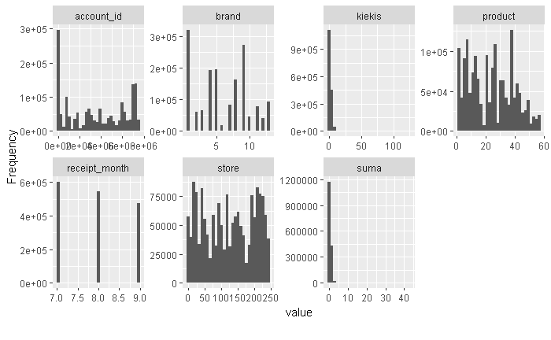

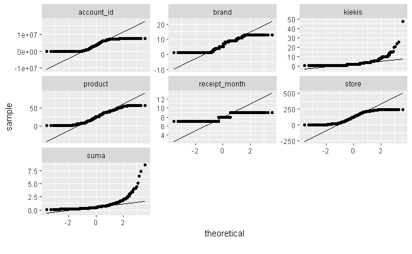

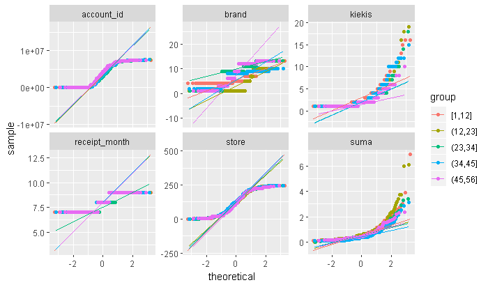

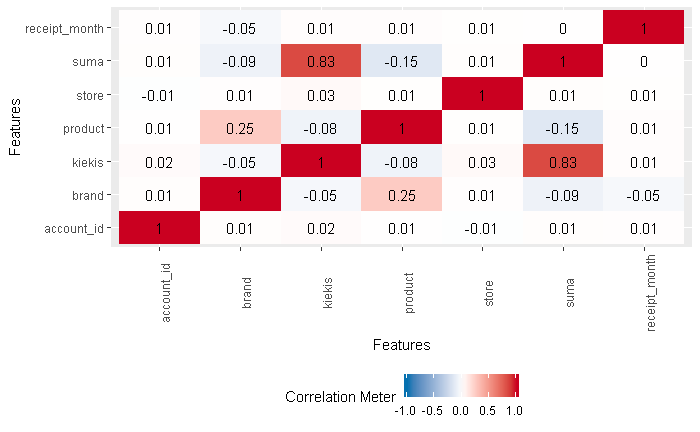

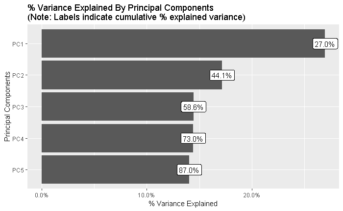

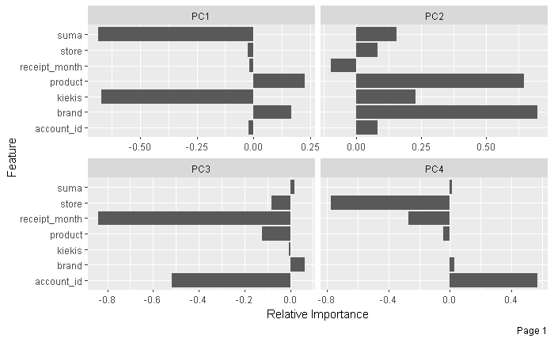

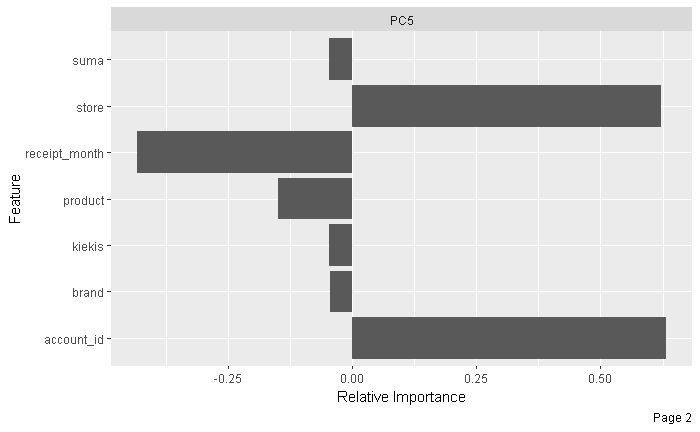

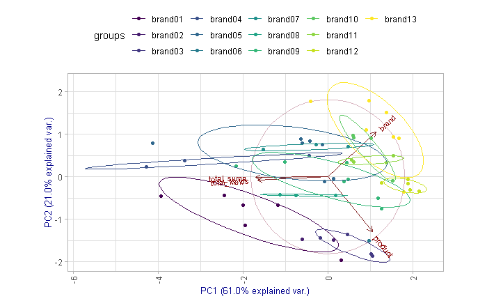

Matyti, kad grupės Suma-Kiekis, Brand-Produktas tarpusavyje koreliuoja. Ši informacija bus naudinga atliekant klasteriavimą toliau.